# Hansen et al. (2006) Notes

# Abstract:

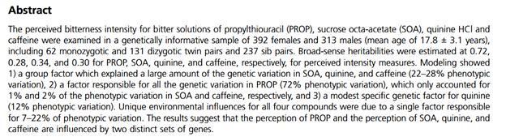

*Abstract of Hansen et al (2006)*

The methods from Hwang et al. (2018) are described in detail here.

# Intro

- 50% of variance in PTC detection threshold is due to genetic differences
- 3 SNPs/5 haplotypes in TAS2R38 on chromosome 7
- aim to investigate “extent of genetic covariation” among sensitivity to PROP, SOA, quinine, and caffeine

# Methods

## Taste test

- 5 bitter samples, presented twice
  - $2*10^{-4}\ M$ SOA
  - $1.81*10^{-4}\ M$ quinine HCl
  - $0.050 \ M$ caffeine
  - $6.0*10^{-4}\ M$ PROP
  - $4.99*10^{-6}\ M$ denatonium benzoate
- presentation of the samples were all the same for all participants
  - different presentation for replicate
- presentation of the bitter samples were interwoven with water and sweet solutions
- a dry PROP strip was also presented (not analyzed in Hansen et al. (2006) but in Hwang et al. (2018))
- analyzed taste sensation on LMS (Green et al. (1996) and ’93)
- Procedure
  - swish for 5 s, spit
  - rate intensity on LMS
  - rate taste quality (5 basic taste)
  - rinse, repeat

## Data Screening and Modeling

- those who total scores were < 200 (average slightly above weak) or > 1800 mm (slightly below strongest imaginable)
- total 705 participants
- denatonium benzoate shwoed bimodal distribution (unable to be transformed in a way that didn’t violate the assumption of normality for data analysis)
- covariates included: age, sex, history of head injury, history of ear infection, smoking behavior, perfume/cologne/aftershave use)
  - significant fixed covariates would be applied to the multivariate modeling

# Results

- clustering from Delwiche, Buletic, and Breslin (2001) seems to hold here, correlations between SOA, quinine, and caff; also lack of correlation of PROP to other bitter compounds
- significant fixed effects (covariates) included age, sex, ear infection history, presentation order
  - bitterness sensitivity decreases with increasing age
  - sex effect: males found SOA more intense (sig); females found quinine more intense (NS)
  - ear infection history tended to increase bitter sensitivity (increased scores)
- MZ twins correlations were high for each bitter taste phenotype, suggesting genetic influence
  - SOA, quinine, caff correlations were more than doubled
    - suggests “nonadditive genetic influence”
  - PROP correlations were half than DZ twin correlations
    - suggests “common environmental factors”
- modeling had low power to detect common environmental factors (C) and discriminate additive genetic (A) and non-additive genetic (D) factors
- heritability estimates were 0.72 for PROP, 0.28 for SOA, 0.34 for quinine, and 0.30 for caffeine
  - increased heritability estimate means direct/indirect genetic variation accounts for the variation in the trait ([Neele Lab](https://www.nealelab.is/blog/2017/9/13/heritability-101-what-is-heritability#:~:text=A%20high%20heritability%2C%20close%20to,to%20be%20informative%20%5B4%5D.))

# Discussion

# References

Delwiche, Jeannine F, Zivjena Buletic, and Paul A S Breslin. 2001. “Covariation in Individuals’ Sensitivities to Bitter Compounds: Evidence Supporting Multiple Receptor/Transduction Mechanisms.” *Percept. Psychophys.* 63 (5): 761–76.

Green, Barry G., Pamela Dalton, Beverly Cowart, Greg Shaffer, Krystyna Rankin, and Jennifer Higgins. 1996. “Evaluating the ’Labeled Magnitude Scale’ for Measuring Sensations of Taste and Smell.” https://academic.oup.com/chemse/article/21/3/323/274584.

Hansen, J. L., Danielle Reed, Margaret Wright, Nicholas Martin, and Paul Breslin. 2006. “Heritability and Genetic Covariation of Sensitivity to Prop, SOA, Quinine Hcl, and Caffeine.” *Chemical Senses* 31 (5): 403–13. https://doi.org/10.1093/chemse/bjj044.

Hwang, Liang-Dar, Puya Gharahkhani, Paul A. S. Breslin, Scott D. Gordon, Gu Zhu, Nicholas G. Martin, Danielle R. Reed, and Margaret J. Wright. 2018. “Bivariate Genome-Wide Association Analysis Strengthens the Role of Bitter Receptor Clusters on Chromosomes 7 and 12 in Human Bitter Taste.” *BMC Genomics* 19 (1): 678. https://doi.org/10.1186/s12864-018-5058-2.